# EDA_Final_Draft

Julia Lin, Jessie Hao, Grace Song

2025-02-26, revised 2025-04-28

# Introduction and Background

Diabetes is a major public health concern in the United States, with significant disparities in prevalence and mortality across racial and ethnic groups. Research has shown that non-Hispanic Black, Hispanic, and Native American populations face higher rates of diabetes-related complications and mortality compared to non-Hispanic White individuals, driven by a combination of biological, social, and healthcare system factors (Spanakis & Golden, 2013). These disparities not only contribute to a greater burden of disease within these communities but also reflect broader systemic issues in healthcare equity and chronic disease management among certain racial minorities. Understanding these patterns is essential for developing policies that promote better healthcare access, improve patient outcomes, and reduce long-term healthcare costs associated with diabetes complications.

To explore these disparities, we analyze the dataset titled United States Diabetes Mortality by County, Race, and Ethnicity 2000–2019 from the Institute for Health Metrics and Evaluation (IHME). This dataset offers annual, county-level mortality estimates stratified by race and ethnicity, allowing for a comprehensive examination of disparities across different demographic groups and geographic regions. By focusing on the 2015 to 2019 period, our analysis captures the most up-to-date pre-pandemic trends, avoiding the confounding effects of COVID-19, which significantly altered diabetes-related mortality patterns due to healthcare disruptions and increased disease severity among diabetic patients (Bashar et al., 2023).

We begin our analysis by identifying the racial populations with the highest diabetes-related mortality rates in the U.S. We first generate the summary statistics of mortality patterns and trends for this racial group. For better visualization, we transform diabetes mortality rate from the dataset into mortality per 10,000,000 population. We further examine geographic factors driving diabetes mortality by aggregating and mapping mortality rates across counties and states, highlighting regional variations that may suggest environmental or healthcare access-related influences.

# Data Preparation

### Input Datasets

Fist prepare the environment for our research project, and load raw annual datasets on diabetes from 2015 to 2019.

```r
# Load the 2015-2019 dataset
data_2015 <- read.csv("data/IHME_USA_DIABETES_COUNTY_RACE_ETHN_2000_2019_MX_2015_BOTH_Y2025M02D10.csv")
data_2016 <- read.csv("data/IHME_USA_DIABETES_COUNTY_RACE_ETHN_2000_2019_MX_2016_BOTH_Y2025M02D10.csv")
data_2017 <- read.csv("data/IHME_USA_DIABETES_COUNTY_RACE_ETHN_2000_2019_MX_2017_BOTH_Y2025M02D10.csv")
data_2018 <- read.csv("data/IHME_USA_DIABETES_COUNTY_RACE_ETHN_2000_2019_MX_2018_BOTH_Y2025M02D10.csv")
data_2019 <- read.csv("data/IHME_USA_DIABETES_COUNTY_RACE_ETHN_2000_2019_MX_2019_BOTH_Y2025M02D10.csv")
```

### Load Library

Before proceeding with analysis, we first loaded the necessary R packages. These include tools for data manipulation (dplyr), statistical analysis (stats), visualization (ggplot2, viridis), and geospatial mapping (sf, maps, mapdata). To keep the output clean, we use suppressPackageStartupMessages() when loading packages.

```r
suppressPackageStartupMessages(library(dplyr))
library(ggplot2)
library(stats)
library(knitr)
library(viridis)
library(sf)
library(maps)
library(mapdata)
library(dplyr)
```

### Combine Datasets

In this step, we first consolidated multiple annual datasets into a single dataset for later analysis. After combination, the dataset contains the death rate of diabetes across various demographical and geographical conditions from 2015 to 2019.

```r
combined_data <- rbind(data_2015, data_2016, data_2017, data_2018, data_2019)
colnames(combined_data)
```

```
##  [1] "measure_id"    "measure_name"  "location_id"   "location_name"
##  [5] "fips"          "race_id"       "race_name"     "sex_id"
##  [9] "sex_name"      "age_group_id"  "age_name"      "cause_id"
## [13] "cause_name"    "year"          "metric_id"     "metric_name"
## [17] "val"           "upper"         "lower"
```

### Find the Race Group with the Highest Death Rate

With the background information provided in the introduction, different racial groups exhibited various death rates with diabetes.Thus, to conduct a deeper analysis in the variables correlated with diabetes death rate, we focused on one specific ethnicity group to better understand health outcomes and target interventions.

```r
# Filter and remove repeated summary data
total_data <- combined_data[combined_data$location_name == "United States of America", ]
filtered_data <- total_data[total_data$race_name != "Total" & total_data$age_group_id == 22, ]

# Aggregate the val column by race, summing up the values
aggregated_data <- aggregate(val ~ race_name, data = filtered_data, sum)

# Calculate the annual death rate by dividing the total val by 5
aggregated_data$annual_death_rate <- aggregated_data$val / 5

# Find the race with the highest annual death rate
highest_death_rate_race <- aggregated_data[which.max(aggregated_data$annual_death_rate), ]

# Print the race with the highest annual death rate and the rate
print(highest_death_rate_race)
```

```
##   race_name        val annual_death_rate
## 1      AIAN 0.00153969      0.0003079379
```

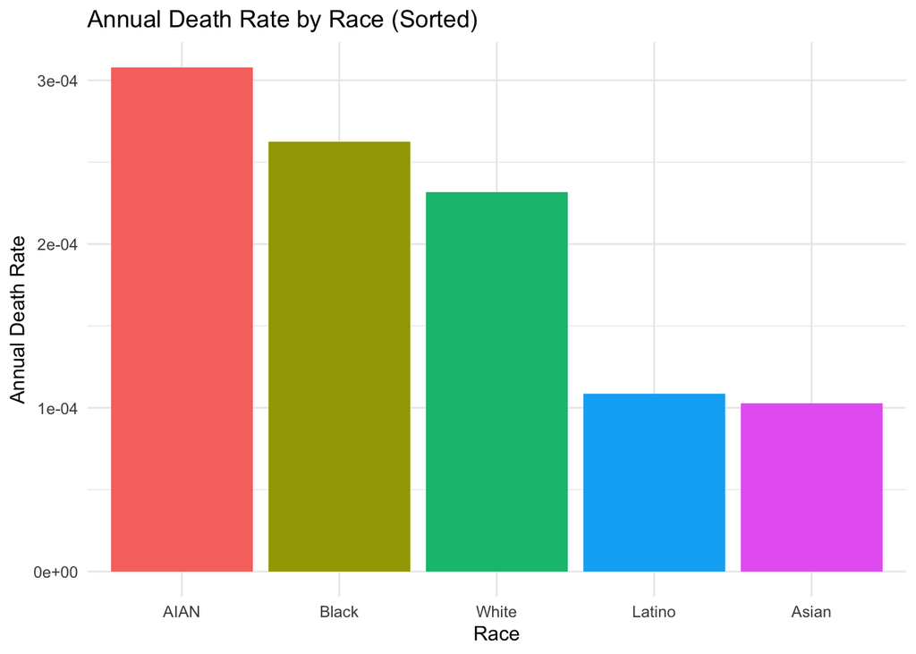

```r
# Reorder race_name based on annual_death_rate (descending)
aggregated_data$race_name <- reorder(aggregated_data$race_name, -aggregated_data$annual_death_rate)

# Create the bar plot
ggplot(aggregated_data, aes(x = race_name, y = annual_death_rate, fill = race_name)) +
  geom_bar(stat = "identity") +
  labs(title = "Annual Death Rate by Race (Sorted)",
       x = "Race",
       y = "Annual Death Rate") +
  theme_minimal() +
  theme(legend.position = "none")
```

Since **the non-Hispanic American Indian or Alaska Native [AIAN]** got the highest death rate, we decide to focus on this particular racial group. Our goal is to investigate whether the high overall mortality rate is correlated with other variables such as age and location.

### Data Cleaning and Filtering

After finding the AIAN to be the racial group with highest mortality rate, we conducted further data filtration and data cleaning.Only AIAN grace group was chosen for precise analysis. At the same time, since the original dataset contained summary variables like”All Ages” and “Age-standardized”, which cannot represents the variability of counties in mortality rates among each individual groups, the summary statistical variables were also dropped out. To better manage the data, only the most relevant columns for analysis were kept, including location identifiers, age categories, and the mortality with their confidence intervals, To ensure the integrity of statistical calculations, we also excluded rows with missing data in numerical variables (“val”, “upper”, and “lower”). Finally, to ensure better visualization across different populations, we scaled our death rate estimates by multiplying 10,000,000, transforming the death rate to the death per 10,000,000. In the analysis below, the scaled estimates of death per 10,000,000 will be addressed as mortality/death rate for simplicity.

```r
# Filter out the race group "AIAN" from the combined_data
AIAN_data <- combined_data %>%
  filter(
    race_name == "AIAN",
    age_name != "All Ages",
    age_name != "Age-standardized"
  ) %>%
  select(
    location_id, location_name, age_group_id,
    age_name, year, val, upper, lower
  ) %>%
  filter(!is.na(val) & !is.na(upper) & !is.na(lower)) %>%
  mutate(value_scaled = val * 10000000)
```

This step extracted the information that will be useful for later analysis. Since the data set shows the information of all inputs in the AIAN race group, repetitive information is neglected in this step.

### Variables of the cleaned data

```r
# Show variables of the cleaned data
colnames(AIAN_data)
```

```
## [1] "location_id"   "location_name" "age_group_id"  "age_name"
## [5] "year"          "val"           "upper"         "lower"
## [9] "value_scaled"
```

| Variables | Definition |
| --- | --- |
| location_id | A unique numeric identifier for the location, including county and state codes |
| location_name | Location of the estimates |
| age_group_id | A unique numeric identifier for each age group |
| age_name | The range of each age group of each estimate |
| year | The year of data collected |
| val | Mean death rate in each group |
| upper | 97.5% percentile estimate |
| lower | 2.5% percentile estimate |
| value_scaled | Mean death per 10,000,000 |

# Basic Distribution and Statistics

### Histogram of diabetes death rates

Examining the distribution of diabetes-related death rates among AIAN individuals provides crucial insights into the variability and patterns in mortality rates across this population. A symmetrical distribution suggests that most AIAN individuals experience similar mortality rates, with fewer extreme cases. A skewed distribution could indicate that certain regions or subpopulations face disproportionately high or low mortality rates. It is also crucial to identify any outliers. Outliers may represent counties with exceptionally high mortality rates, which could signal healthcare access issues, socioeconomic disparities, or genetic predispositions. Conversely, outliers on the lower end may indicate areas with effective diabetes management and preventive care.

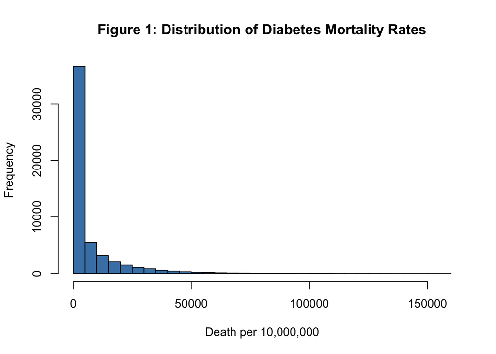

```r
hist(AIAN_data$value_scaled,
     main = "Figure 1: Distribution of Diabetes Mortality Rates",
     xlab = "Death per 10,000,000",
     col = "steelblue",
     border = "black",
     breaks = 30)
```

Understanding the distribution of mortality rates is fundamental to this project because it provides a high-level overview of disparities before diving into specific geographic and demographic factors.

As the distribution is highly right-skewed, it indicates that most counties fall within a low mortality range, suggesting widespread but moderate impact of diabetes and a few counties are disproportionately affected by diabetes mortality. This helps us target specific geographic areas or demographical group for further investigation. The wide distribution also indicates large variability, suggesting that AIAN communities may have unequal access to healthcare, differences in socioeconomic conditions, or variations in diabetes management programs.

### Boxplot of death rates across age groups

The above histogram suggests that there is variability of diabetes mortality rate and suggesting specific geographical and demographical factors may contribute to such disparities. Thus, this project will investigate how do these variables affect the mortality rate of AIAN community.

Age is a variable that may contribute to the disparity in morality. Previous studies have concluded that diabetes has more impact to middle-age and elder populations. We want to investigate whether such trend holds true for AIAN group, and if age can account for the large variability observed from figure 1.

A boxplot is particularly useful in analyzing diabetes mortality rates across age groups because it provides a clear, concise summary of the distribution, spread, and outliers in the data. Compared to other types of plots, it offers several advantages. A boxplot visualizes the entire distribution within each age group, capturing key statistical measures—median, quartiles, minimum, maximum, and outliers—all in one plot. This visualization is essential for understanding how age influences mortality risk and identifying potential disparities in diabetes-related health outcomes. Compared to a histogram, which only shows the distribution of a single variable, a boxplot also compares multiple age groups simultaneously, which better shows trends in mortality rates across age groups.

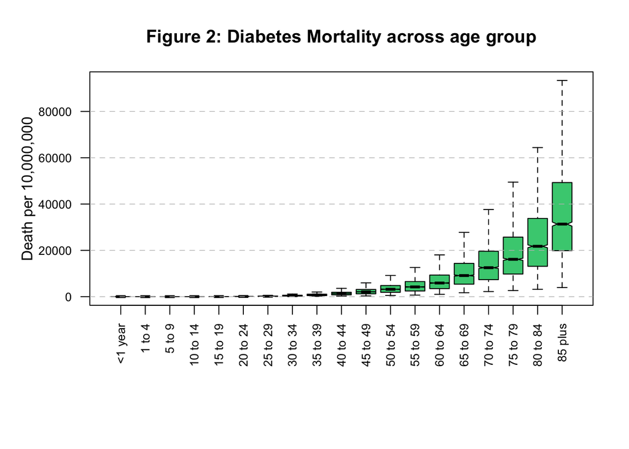

```r
# Convert 'age_name' to a factor with the specified order
age_order <- c("<1 year", "1 to 4", "5 to 9", "10 to 14", "15 to 19",
               "20 to 24", "25 to 29", "30 to 34", "35 to 39", "40 to 44",
               "45 to 49", "50 to 54", "55 to 59", "60 to 64", "65 to 69",
               "70 to 74", "75 to 79", "80 to 84", "85 plus")

AIAN_data$age_name <- factor(AIAN_data$age_name, levels = age_order, ordered = TRUE)

boxplot(value_scaled ~ age_name, data = AIAN_data,
        las = 2,
        main = "Figure 2: Diabetes Mortality across age group",
        xlab = "",
        ylab = "Death per 10,000,000",
        col = "seagreen3",
        border = "black",
        notch = TRUE,
        outline = FALSE,
        cex.axis = 0.8,
        par(mar = c(8, 5, 4, 2)))
grid(nx = NA, ny = NULL, lty = "dashed", col = "gray", lwd = 0.7)
```

Figure 2 is a boxplot that visually represents diabetes mortality rates across different age groups within the AIAN population. This figure provides a summary of the spread, central tendency, and variability of mortality rates for each age category, allowing for a clear comparison of diabetes-related deaths among different age groups.

# Analysis and Visualization

We identified that there are potential factors causing the wide variability of diabetes mortality rates among AIAN populations from the above analysis, so then we explore how more specific factors affect diabetes mortality rate among AIAN communities. Understanding the factors that influence diabetes mortality is crucial for addressing disparities among AIAN populations. Since diabetes-related deaths are not uniform across all demographics, it is essential to examine how age, geographic location (county and state), and healthcare access impact mortality rates. Different age groups face varying risks, with older populations often experiencing higher mortality due to complications, while younger groups may indicate emerging public health concerns. Additionally, disparities at the county and state level can highlight regional differences in healthcare access, socioeconomic conditions, and policy effectiveness, which directly affect health outcomes. By investigating these factors in depth, we can identify the most vulnerable populations, uncover regional disparities, and guide targeted interventions to reduce diabetes-related deaths.

## Difference in death rate by age groups

### Define age categories

```r
age_AIAN_data <- AIAN_data %>%
  mutate(age_group = case_when(
    age_name %in% c("<1 year", "1 to 4") ~ "Infant/Young Child",
    age_name %in% c("5 to 9", "10 to 14", "15 to 19") ~ "Child/Teen",
    age_name %in% c("20 to 24", "25 to 29", "30 to 34", "35 to 39", "40 to 44") ~ "Young Adult",
    age_name %in% c("45 to 49", "50 to 54", "55 to 59", "60 to 64") ~ "Middle-Aged Adult",
    age_name %in% c("65 to 69", "70 to 74", "75 to 79", "80 to 84", "85 plus") ~ "Elderly",
    TRUE ~ "Unknown"
  ))
```

### Distribution of each age group

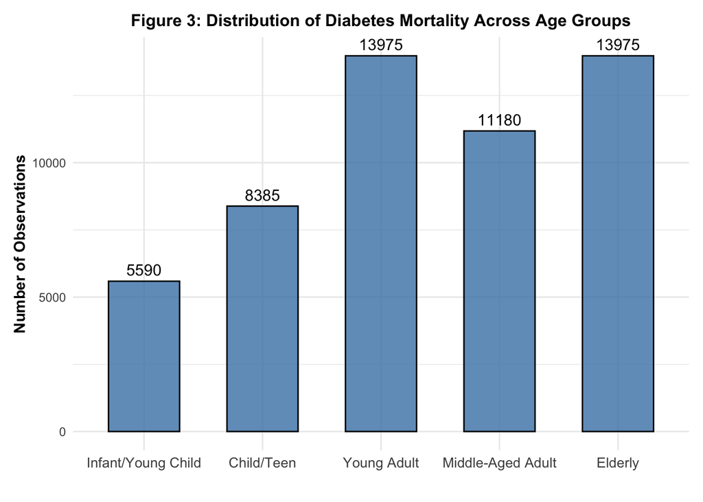

```r
# Convert age_group into a factor with the specified order
age_group_order <- c("Infant/Young Child", "Child/Teen", "Young Adult", "Middle-Aged Adult", "Elderly")

# Group data by age group and count occurrences
age_distribution <- age_AIAN_data %>%
  group_by(age_group) %>%
  summarise(count = n()) %>%
  mutate(age_group = factor(age_group, levels = age_group_order, ordered = TRUE))


ggplot(age_distribution, aes(x = age_group, y = count)) +
  geom_bar(stat = "identity", fill = "steelblue", color = "black", alpha = 0.8, width = 0.6) +
  labs(title = "Figure 3: Distribution of Diabetes Mortality Across Age Groups",
       x = "",
       y = "Number of Observations") +
  theme_minimal() +
  theme(
    axis.text.x = element_text(size = 10),
    axis.title = element_text(face = "bold"),
    plot.title = element_text(hjust = 0.5, face = "bold", size = 12),
    plot.margin = margin(10, 10, 10, 10)
  ) +
  geom_text(aes(label = count), vjust = -0.5, size = 4)
```

### Summary statistics by age group

```r
age_summary <- age_AIAN_data %>%
  group_by(age_group) %>%
  summarise(
    mean_unit_death = mean(value_scaled, na.rm = TRUE),
    sd_unit_death = sd(val, na.rm = TRUE),
    median_unit_death = median(value_scaled, na.rm = TRUE),
    min_unit_death = min(value_scaled, na.rm = TRUE),
    max_unit_death = max(value_scaled, na.rm = TRUE),
    count = n()
  ) %>%
  arrange(desc(mean_unit_death))

print(age_summary)
```

```
## # A tibble: 5 × 7
##   age_group       mean_unit_death sd_unit_death median_unit_death min_unit_death
##   <chr>                     <dbl>         <dbl>             <dbl>          <dbl>
## 1 Elderly                 21265.    0.00174              16318.         1712.
## 2 Middle-Aged Ad…          4605.    0.000392              3449.          331.
## 3 Young Adult               629.    0.0000754              377.           16.2
## 4 Child/Teen                 17.2   0.00000200               9.55          0.828
## 5 Infant/Young C…            11.6   0.000000886              9.03          1.28
## # ℹ 2 more variables: max_unit_death <dbl>, count <int>
```

### Visualization of mean death rate in each age group

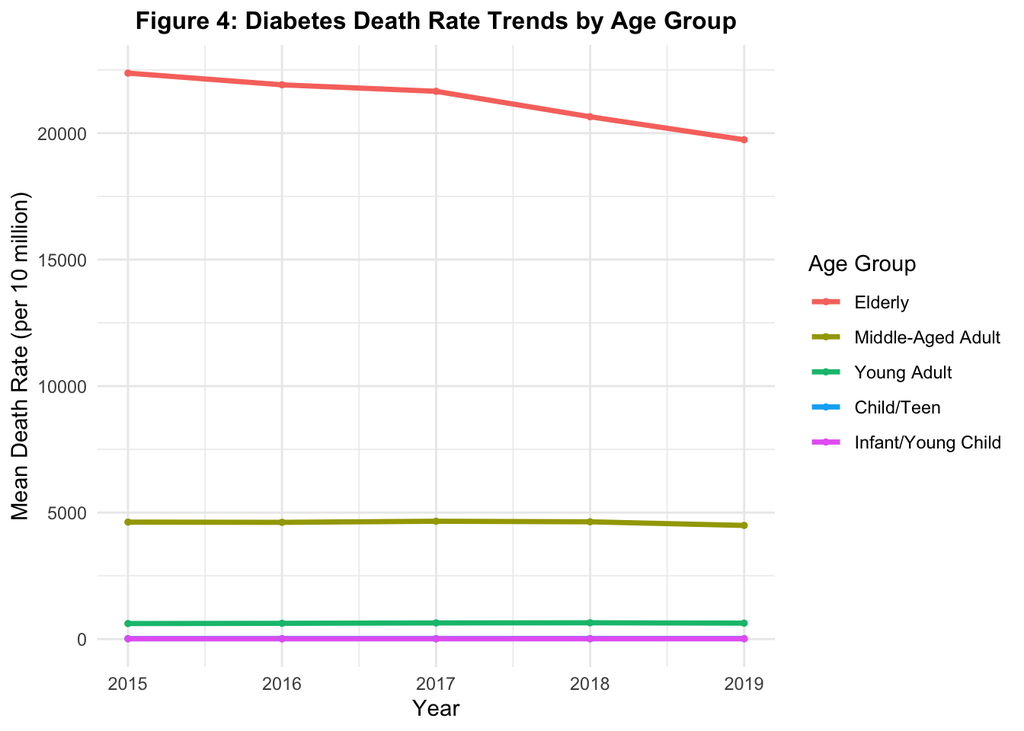

```r
# Summarize average death rate per age group per year
age_group_order <- age_AIAN_data %>%
  group_by(age_group) %>%
  summarize(overall_mean = mean(value_scaled, na.rm = TRUE)) %>%
  arrange(desc(overall_mean)) %>%
  pull(age_group)

# Step 2: Summarize by year and age group, and apply the factor levels
age_trend <- age_AIAN_data %>%
  group_by(age_group, year) %>%
  summarize(mean_death_rate = mean(value_scaled, na.rm = TRUE), .groups = "drop") %>%
  mutate(age_group = factor(age_group, levels = age_group_order))

# Step 3: Plot
ggplot(age_trend, aes(x = year, y = mean_death_rate, color = age_group)) +
  geom_line(size = 1.2) +
  geom_point(size = 1) +
  labs(
    title = "Figure 4: Diabetes Death Rate Trends by Age Group",
    x = "Year",
    y = "Mean Death Rate (per 10 million)",
    color = "Age Group"
  ) +
  theme_minimal()+
  theme(
    plot.title = element_text(hjust = 0.5, face = "bold", size = 12)
  )
```

Figure 4 shows the mean diabetes-related death rate (per 10 million people) over time across different age groups. The elderly group consistently had the highest death rate, with a slight downward trend from 2015 to 2019. Middle-aged adults maintained the second highest rates, showing relatively little change across the years. Young adults, children/teens, and infants/young children exhibited substantially lower death rates compared to older age groups, with minimal fluctuations over time. Overall, while diabetes mortality was highest among the elderly, a gradual decline is observed, whereas mortality rates for younger groups remained relatively stable.

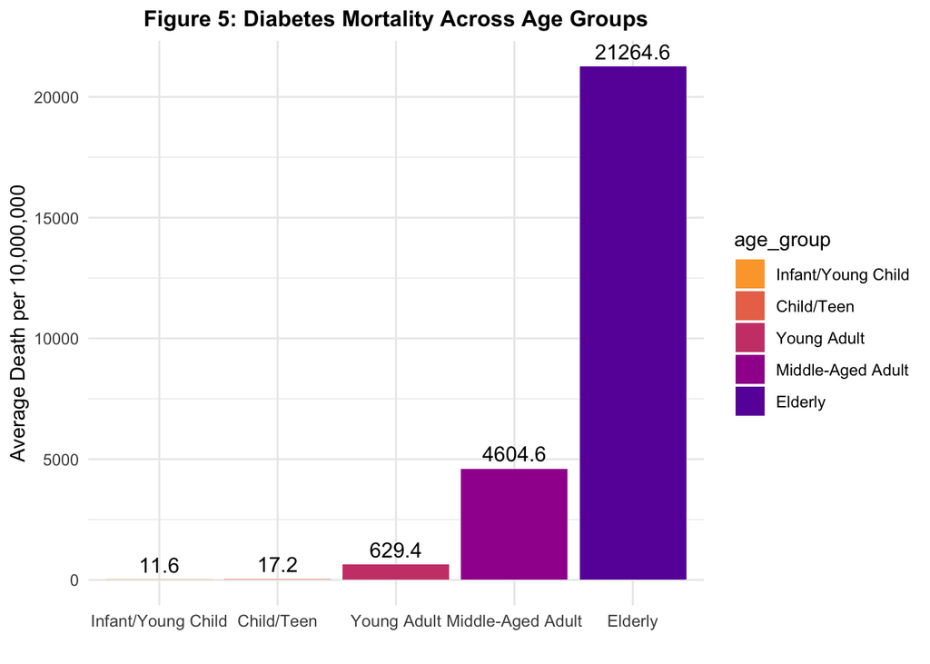

```r
age_summary$age_group<-factor(age_summary$age_group, levels = rev(unique(age_summary$age_group)))
ggplot(age_summary, aes(x = reorder(age_group, mean_unit_death), y = mean_unit_death, fill = age_group)) +
  geom_bar(stat = "identity") +
  scale_fill_viridis(discrete = TRUE, option = "C", begin = 0.8, end = 0.2) +  # Reversed scale
  labs(title = "Figure 5: Diabetes Mortality Across Age Groups",
       x = "",
       y = "Average Death per 10,000,000") +
  theme_minimal() +
  theme(
    axis.text.x = element_text(size = 9),
    plot.title = element_text(hjust = 0.5, face = "bold", size = 12)
  ) +
  geom_text(aes(label = round(mean_unit_death, 1)), vjust = -0.5, size = 4)  # Round for better visualization
```

## Difference of death rate by locations

After examining the contribution of different age groups to diabetes mortality, geographic variation emerges as another key factor potentially affecting the observed racial disparities. Exploring differences across counties and states can provide further insight into systemic factors contributing to the elevated mortality rates within the AIAN population.

### Difference in mean death rate by locations (county-level)

To begin our analysis, we first focus on the county-level differences in diabetes mortality among AIAN populations. Since counties represent more localized healthcare and socioeconomic environments, examining mortality rates at this level allows us to identify specific areas where the burden of diabetes is most severe. By identifying the top ten counties with the highest average mortality rates, we can highlight the regions facing the greatest challenges. Once these high-burden counties are identified, we then broaden our analysis to explore state-level trends, assessing whether certain states have a disproportionately high mortality burden across multiple counties.

First, the dataset (AIAN_data) is filtered to retain only county-level data by selecting rows where the location_name contains parentheses, as county names are typically formatted this way in the dataset. This ensures that only county-level mortality rates are considered in the analysis.

```r
county_AIAN_data <- AIAN_data %>%
  filter(grepl("\\(", location_name))
```

Next, the filtered dataset (county_AIAN_data) is grouped by county names (location_name), and the mean mortality rate (value_scaled) is computed for each county, ignoring any missing values (na.rm = TRUE). The counties are then arranged in descending order based on their average mortality rates, and the top ten counties with the highest rates are displayed

```r
county_summary <- county_AIAN_data %>%
  group_by(location_name) %>%
  summarize(avg_unit_death = mean(value_scaled, na.rm = TRUE)) %>%
  arrange(desc(avg_unit_death)) %>%
  slice(1:10)

print(county_summary)
```

```
## # A tibble: 10 × 2
##    location_name                   avg_unit_death
##    <chr>                                    <dbl>
##  1 Neshoba County (Mississippi)            37406.
##  2 Newton County (Mississippi)             21329.
##  3 Cumberland County (New Jersey)          20393.
##  4 Caddo County (Oklahoma)                 19291.
##  5 Washington County (Maine)               18966.
##  6 Uintah County (Utah)                    18541.
##  7 Adair County (Oklahoma)                 18310.
##  8 Minnehaha County (South Dakota)         18054.
##  9 Blaine County (Oklahoma)                17880.
## 10 Leake County (Mississippi)              17820.
```

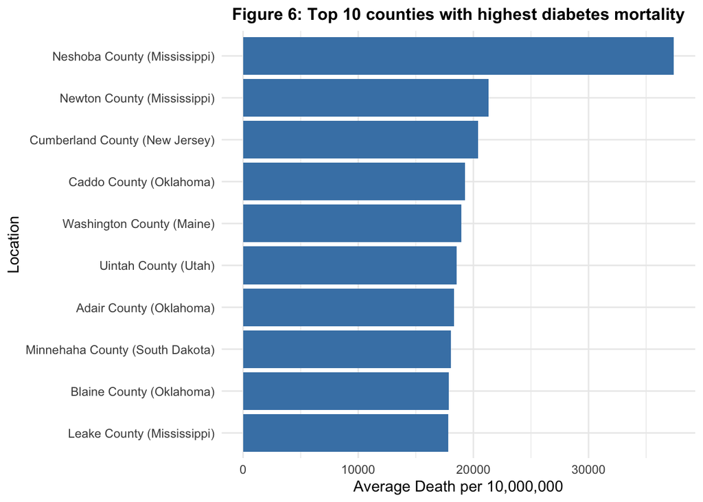

```r
ggplot(county_summary, aes(x = reorder(location_name, avg_unit_death), y = avg_unit_death)) +
  geom_bar(stat = "identity",fill = "steelblue") +
  coord_flip() +
  labs(title = "Figure 6: Top 10 counties with highest diabetes mortality",
       x = "Location", y = "Average Death per 10,000,000") +
  theme_minimal()+
   theme(
    plot.title = element_text(hjust = 0.5, face = "bold", size = 12)
  )
```

### Difference in mean death rate by locations (state-level)

After identifying the counties with the highest diabetes mortality rates among AIAN populations, we now shifted our focus to the state level to examine broader geographic patterns.

```r
state_AIAN_data <- AIAN_data %>%
  filter(grepl("^[A-Za-z]+(?: [A-Za-z]+)?$", location_name))
```

```r
state_summary <- state_AIAN_data %>%
  group_by(location_name) %>%
  summarise(
    mean_death_unit = mean(value_scaled, na.rm = TRUE),
    sd_death_unit = sd(value_scaled, na.rm = TRUE),
    median_death_unit = median(value_scaled, na.rm = TRUE),
    min_death_unit = min(value_scaled, na.rm = TRUE),
    max_death_unit = max(value_scaled, na.rm = TRUE)
  ) %>%
  arrange(desc(mean_death_unit))

print(state_summary)
```

```
## # A tibble: 50 × 6
##    location_name mean_death_unit sd_death_unit median_death_unit min_death_unit
##    <chr>                   <dbl>         <dbl>             <dbl>          <dbl>
##  1 Maine                  14998.        23715.             2597.           6.88
##  2 Rhode Island           13082.        20495.             2056.           5.19
##  3 South Dakota           12592.        19336.             2592.          10.8
##  4 North Dakota           12545.        19591.             2660.          10.2
##  5 Wyoming                12044.        18976.             2372.           7.41
##  6 Mississippi            10801.        12006.             4719.          12.2
##  7 Montana                10729.        16747.             2155.           8.27
##  8 Minnesota              10542.        15395.             2273.           7.88
##  9 Arizona                 9505.        13662.             2583.           7.17
## 10 Utah                    9493.        14526.             2219.           6.08
## # ℹ 40 more rows
## # ℹ 1 more variable: max_death_unit <dbl>
```

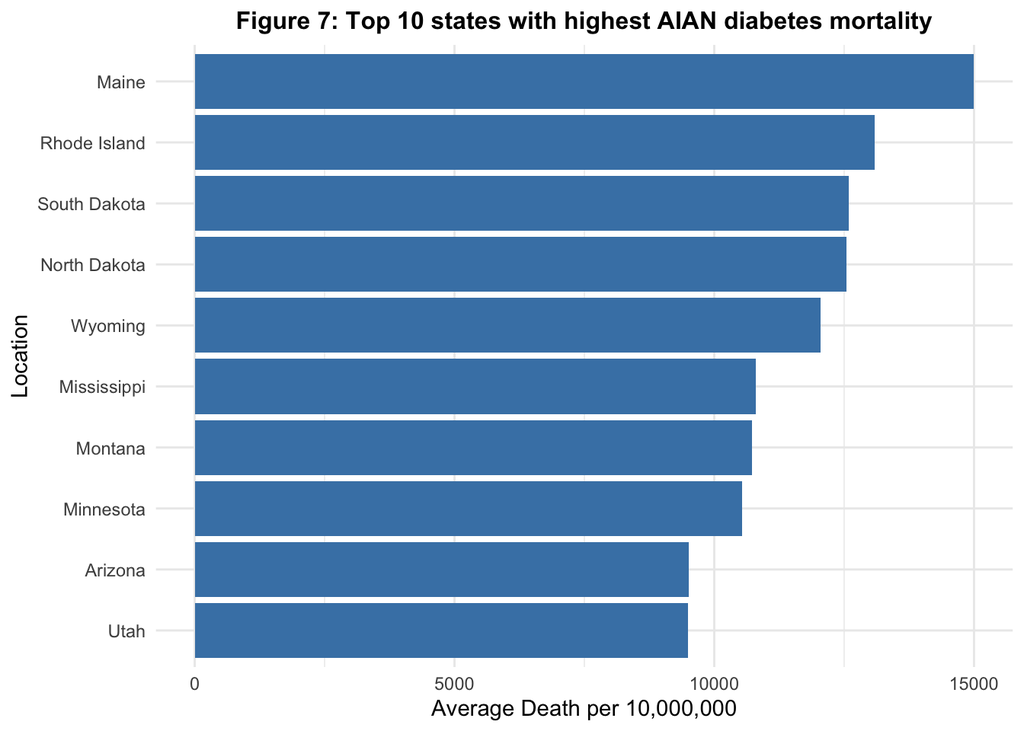

```r
location_avg <- state_AIAN_data %>%
  group_by(location_name) %>%
  summarize(avg_death_unit = mean(value_scaled, na.rm = TRUE)) %>%
  arrange(desc(avg_death_unit)) %>%
  slice(1:10)

ggplot(location_avg, aes(x = reorder(location_name, avg_death_unit), y = avg_death_unit)) +
  geom_bar(stat = "identity",fill = "steelblue") +
  coord_flip() +
  labs(title = "Figure 7: Top 10 states with highest AIAN diabetes mortality",
       x = "Location", y = "Average Death per 10,000,000") +
  theme_minimal()+
   theme(
    plot.title = element_text(hjust = 0.5, face = "bold", size = 12)
  )
```

### Visualizing state-level diabetes mortality through map

After visualizing the top states with the highest AIAN diabetes mortality rates through a bar plot, we extend our analysis by mapping state-level mortality trends across the U.S. While a bar plot effectively highlights the most affected states, a geospatial representation allows us to examine regional disparities more comprehensively.So we decided to visualize diabetes mortality on a map to better understand how mortality rates vary across states.

To generate this map, we first loaded U.S. state boundaries using map_data(“state”), which provides the necessary geographic outline. Next, we calculated the average mortality rate for each state by grouping the dataset state_AIAN_data by location_name and computing the mean of value_scaled.

Since the map_data(“state”) dataset uses lowercase state names, we ensured consistency by converting the location_name column to lowercase before merging it with the state boundary data.

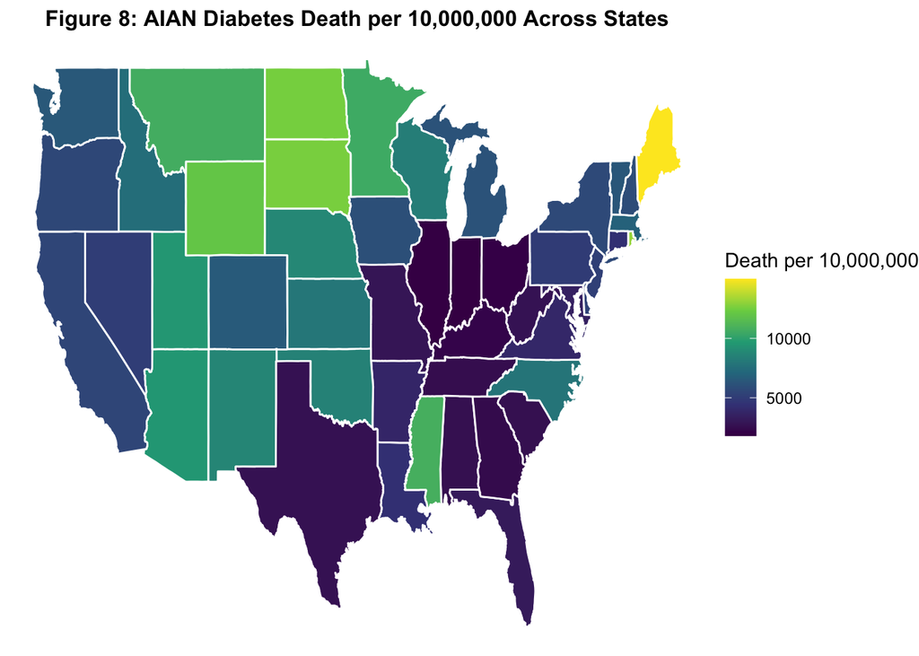

```r
us_states <- map_data("state")

location_avg_all <- state_AIAN_data %>%
  group_by(location_name) %>%
  summarize(avg_death_unit = mean(value_scaled, na.rm = TRUE)) %>%
  arrange(desc(avg_death_unit))

location_avg_new <- location_avg_all %>%
  mutate(location_name = tolower(location_name))

# Merge state boundaries with mortality data
map_data <- us_states %>%
  left_join(location_avg_new, by = c("region" = "location_name"))

ggplot(map_data, aes(long, lat, group = group, fill = avg_death_unit)) +
  geom_polygon(color = "white") +
  scale_fill_viridis_c(option = "viridis", name = "Death per 10,000,000") +
  theme_void() +
  labs(
    title = "Figure 8: AIAN Diabetes Death per 10,000,000 Across States"
  ) +
  theme(
    plot.title = element_text(hjust = 0.5, face = "bold", size = 12),
    legend.position = "right"
  )
```

# Conclusion and Futher implication

The current study demonstrates AIAN as the racial group with the highest diabetes-related mortality rates and determined some risk factors for this burden. By using the county and state rates of mortality time series data spanning from 2015 to 2019, we have pinpointed the large differences in diabetes-related mortality rates in terms of age and geographic locations in the United States of AIAN populations.

This study also provides insights on potential factors that can impact the diabetes mortality rates in AIAN population, for example, whether there is large proportion of elderly individuals who are especially susceptible to diabetes. In addition, whether risk factors related to regional distribution could also impact the diabetes mortality rates, such as healthcare coverage and access to healthcare.

We have observed that diabetes mortality does not follow one course of the population but varies among AIAN groups. Relatively early in life, death rates in middle-aged and elderly persons are much worse, illustrating the fact that diabetes complications get worse with age. Moreover, geographic variations in mortality rates are seen across different counties and states, with specific places reporting them consistently. A number of Mississippi and Oklahoma regions are the most affected, while the states of Maine, Rhode Island, South Dekota, North Dekota, and Wyoming present the top 5 average mortality rate. The striking conclusions indicate a possible systemic determinant that could include confined medical access, socioeconomic deprivation, or inconsistent programs of diabetes prevention and care within the AIAN populations.

The geographic and demographic disparities revealed in this study highlight the urgency for specific public health interventions. Closing the gap in mortality rates necessitates a comprehensive blend of strategies, including: 1) establishing more diabetes diagnostic and treatment centers in high-mortality counties and regions; 2) engaging AIAN communities more effectively through the implementation of cultural and tradition-informed diabetes prevention programs; 3) advancing diabetes screenings across all demographic groups but specifically among middle-aged and elderly individuals.

Based on this analysis, further research could be conducted to deepen our understanding of diabetes-related mortality disparities among AIAN populations. While we intentionally focused on pre-pandemic data to avoid confounding effects in our findings, future studies could incorporate post-pandemic data to assess whether and to what extent COVID-19 influenced diabetes-related mortality rates. Comparative analysis could be done between pre- and post-pandemic data to obtain a more comprehensive understanding of the pandemic influence.

# Reference

Institute for Health Metrics and Evaluation (IHME). United States Diabetes Mortality by County, Race, and Ethnicity 2000-2019. Seattle, United States of America: Institute for Health Metrics and Evaluation (IHME), 2025.

This is the dataset we use for our analysis

Spanakis, Elias K., and Sherita Hill Golden. “Race/Ethnic Difference in Diabetes and Diabetic Complications.” Current Diabetes Reports, vol. 13, no. 6, 15 Sept. 2013, pp. 814–823, www.ncbi.nlm.nih.gov/pmc/articles/PMC3830901/, https://doi.org/10.1007/s11892-013-0421-9.

This article investigates the racial difference in terms of diabetes incidence and complications, which is the motivation for our study

Bashar, Hussein, et al. “Impact of the COVID‐19 Pandemic on Diabetes‐Related Cardiovascular Mortality in the United States.” Journal of the American Heart Association, vol. 12, no. 13, 29 June 2023, https://doi.org/10.1161/jaha.122.028896. Accessed 6 Nov. 2024.

This article suggests that COVID-19 may contribute to an increase in diabetes-related cardiovascular mortality. To eliminate potential confounding factors associated with the pandemic, we select the dataset that includes only data from 2000 to 2019.